# Multivariate Component analysis

## First dataset

The first dataset analyzed is the connectome dataset. The file `connectome_vectorized.csv.gz`contains information about brain connectivity for men and woman. Rows represent boolean values indicating wheether a connections between two brain areas is present or absent. Connections with variance among subjects are included in this study. E.g. there are no connections that are present or absent in all subjects. Last column indicates if the subject is male or female.

### Research question

A relevant and interesting reseachquestion is whether there is a difference in brain connections patterns between men and woman. I would expect that there are differences in brain connection patterns between men and woman because of physiological and hormonal differences among both genders.

### Loading the data

```python
# Loading modules
import pandas as pd
```

```python
# Loading csv file
connectome = pd.read_csv('connectome_vectorized.csv', index_col=0)
print(connectome.head())
print(f'\nDimensions dataset: \nParticipants: {connectome.shape[0]}\nBrain connection booleans: {connectome.shape[1]}')
```

```
   0  1  2  3  4  5  6  7  8  9  ...  93139  93140  93141  93142  93143
0  1  0  0  0  0  0  0  0  0  0  ...      0      0      1      0      0  \
1  0  0  0  0  1  0  1  0  0  0  ...      0      0      0      1      0
2  0  0  1  0  0  0  0  0  0  0  ...      0      0      0      0      0
3  0  0  0  0  1  0  1  0  0  0  ...      0      0      0      0      0
4  0  0  0  0  0  0  0  0  0  0  ...      0      0      0      0      0

   93144  93145  93146  93147  sex
0      1      0      0      0    F
1      1      1      1      1    M
2      1      0      0      1    M
3      1      1      0      1    M
4      1      1      0      1    F

[5 rows x 93149 columns]

Dimensions dataset:
Participants: 96
Brain connection booleans: 93149
```

Above the first five rows of the dataset are printed, accompanied with dimension data of the dataset. In total brain connection data of 96 participants is gathered; 93.148 brain connections per person and a last categorical gender value. Now that the contents of the dataset is clear, missing values are checked. As showed below, no missing data is observed.

```python
# Count NaN values for whole dataset
nan_count = connectome.isna().sum().sum()
print(f'Missing values connectome data: {nan_count}')
```

```
Missing values connectome data: 0
```

### PCA analysis

Since we have access to data of two groups with boolean values, PCA analysis can help us to deeper understand our dataset

```python
# Fetching the right variables for analysis
y = connectome.loc[:,['sex']].values
x = connectome[connectome.columns[:-1]].values
```

```python
from sklearn.decomposition import PCA
import numpy as np

pca = PCA(n_components=10)
principal_components = pca.fit_transform(x)
principal_df = pd.DataFrame(data = principal_components)
principal_df.columns = ["PC" + str(i) for i in range(1,11)]
principal_df.head()
```

|  | PC1 | PC2 | PC3 | PC4 | PC5 | PC6 | PC7 | PC8 | PC9 | PC10 |
| --- | --- | --- | --- | --- | --- | --- | --- | --- | --- | --- |
| 0 | 1.886927 | -8.687815 | -5.081661 | -4.062698 | 5.693521 | -4.840191 | 1.995062 | -3.734645 | 0.820360 | 13.961998 |
| 1 | 0.590685 | 2.842999 | 6.747101 | -6.184555 | -22.898373 | -10.542512 | -1.854356 | 7.967094 | 1.520672 | 3.398630 |
| 2 | -9.439526 | 0.043950 | -1.365210 | 2.136766 | 6.372620 | -9.542842 | -9.342847 | 0.100731 | 1.477864 | -0.000452 |
| 3 | -3.193052 | -6.194300 | 3.881591 | -0.790752 | -3.802242 | 19.051623 | -2.790341 | 2.331828 | -1.598306 | -9.487137 |
| 4 | 16.298299 | 7.147702 | -16.963141 | -5.883632 | -8.066969 | -6.724758 | 7.578597 | 2.709886 | 11.212931 | 2.165905 |

```python
y = [item for sublist in y for item in sublist]
principal_df['sex'] = y
principal_df.head()
```

|  | PC1 | PC2 | PC3 | PC4 | PC5 | PC6 | PC7 | PC8 | PC9 | PC10 | sex |
| --- | --- | --- | --- | --- | --- | --- | --- | --- | --- | --- | --- |
| 0 | 1.886927 | -8.687815 | -5.081661 | -4.062698 | 5.693521 | -4.840191 | 1.995062 | -3.734645 | 0.820360 | 13.961998 | F |
| 1 | 0.590685 | 2.842999 | 6.747101 | -6.184555 | -22.898373 | -10.542512 | -1.854356 | 7.967094 | 1.520672 | 3.398630 | M |
| 2 | -9.439526 | 0.043950 | -1.365210 | 2.136766 | 6.372620 | -9.542842 | -9.342847 | 0.100731 | 1.477864 | -0.000452 | M |
| 3 | -3.193052 | -6.194300 | 3.881591 | -0.790752 | -3.802242 | 19.051623 | -2.790341 | 2.331828 | -1.598306 | -9.487137 | M |
| 4 | 16.298299 | 7.147702 | -16.963141 | -5.883632 | -8.066969 | -6.724758 | 7.578597 | 2.709886 | 11.212931 | 2.165905 | F |

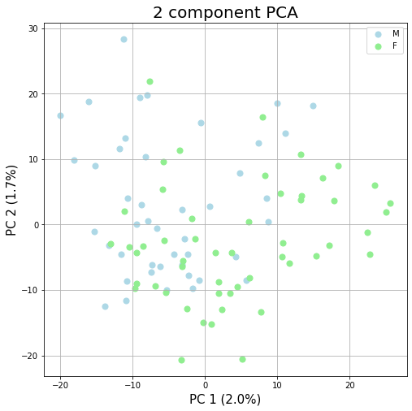

```python
import matplotlib.pyplot as plt

fig = plt.figure(figsize = (8,8))
ax = fig.add_subplot(1,1,1)
ax.set_title('2 component PCA', fontsize = 20)

labels = {
    str(i): f"PC {i+1} ({var:.1f}%)"
    for i, var in enumerate(pca.explained_variance_ratio_ * 100)
}

labels = {
    str(i): f"PC {i+1} ({var:.1f}%)"
    for i, var in enumerate(pca.explained_variance_ratio_ * 100)
}

targets = ['M', 'F']
colors = ['lightblue', 'lightgreen']
for target, color in zip(targets,colors):
    indicesToKeep = principal_df['sex'] == target
    ax.scatter(principal_df.loc[indicesToKeep, 'PC1']
               , principal_df.loc[indicesToKeep, 'PC2']
               , c = color
               , s = 50)
ax.legend(targets)
ax.set_xlabel(list(labels.values())[0], fontsize = 15)
ax.set_ylabel(list(labels.values())[1], fontsize = 15)
ax.grid()
```

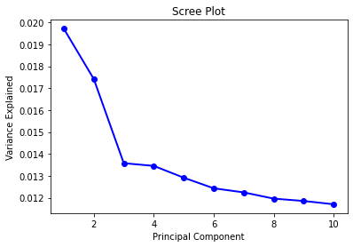

```python
PC_values = np.arange(pca.n_components_) + 1
plt.plot(PC_values, pca.explained_variance_ratio_, 'o-', linewidth=2, color='blue')
plt.title('Scree Plot')
plt.xlabel('Principal Component')
plt.ylabel('Variance Explained')
plt.show()
```

### LDA

```python
from sklearn.discriminant_analysis import LinearDiscriminantAnalysis
from sklearn.model_selection import train_test_split
from sklearn.model_selection import RepeatedStratifiedKFold
from sklearn.model_selection import cross_val_score
from sklearn.discriminant_analysis import LinearDiscriminantAnalysis
```

```python
# Get amount of observations
len(connectome.index)
```

```
96
```

```python
from sklearn.model_selection import train_test_split
x_train, x_test, y_train, y_test = train_test_split(x, y, test_size = 0.2, random_state = 0)
```

```python
from sklearn.preprocessing import StandardScaler

sc = StandardScaler()
x_train = sc.fit_transform(x_train)
x_test = sc.transform(x_test)
```

```python
from sklearn.discriminant_analysis import LinearDiscriminantAnalysis
lda = LinearDiscriminantAnalysis(n_components=1)
x_train = lda.fit_transform(x_train, y_train)
x_test = lda.transform(x_test)
```

```python
from sklearn.ensemble import RandomForestClassifier

classifier = RandomForestClassifier(max_depth=2, random_state=0)

classifier.fit(x_train, y_train)
y_pred = classifier.predict(x_test)
```

```python
y_pred = classifier.predict(x_test)
```

```python
from sklearn.metrics import confusion_matrix
from sklearn.metrics import accuracy_score

cm = confusion_matrix(y_test, y_pred)
print(cm)
print('Accuracy' + str(accuracy_score(y_test, y_pred)))
```

```
[[10  0]
 [ 9  1]]
Accuracy0.55
```

## Second dataset

In this dataset contains measurements of lengths of children and their parent accompanied with the sex of the subjects. On this dataset we will perform regression.

```python
# Loading the dataset

galton = pd.read_csv('galton.dat', sep='\t')
galton[0:10]
```

|  | family | father | mother | gender | height | kids | male | female |
| --- | --- | --- | --- | --- | --- | --- | --- | --- |
| 0 | 1 | 78.5 | 67.0 | M | 73.2 | 4 | 1.0 | 0.0 |
| 1 | 1 | 78.5 | 67.0 | F | 69.2 | 4 | 0.0 | 1.0 |
| 2 | 1 | 78.5 | 67.0 | F | 69.0 | 4 | 0.0 | 1.0 |
| 3 | 1 | 78.5 | 67.0 | F | 69.0 | 4 | 0.0 | 1.0 |
| 4 | 2 | 75.5 | 66.5 | M | 73.5 | 4 | 1.0 | 0.0 |
| 5 | 2 | 75.5 | 66.5 | M | 72.5 | 4 | 1.0 | 0.0 |
| 6 | 2 | 75.5 | 66.5 | F | 65.5 | 4 | 0.0 | 1.0 |
| 7 | 2 | 75.5 | 66.5 | F | 65.5 | 4 | 0.0 | 1.0 |
| 8 | 3 | 75.0 | 64.0 | M | 71.0 | 2 | 1.0 | 0.0 |
| 9 | 3 | 75.0 | 64.0 | F | 68.0 | 2 | 0.0 | 1.0 |

We expect that, using multi linear regression, we can predict the length of a child out of the variables above.

```python
# Nothing wrong with datatypes
galton.dtypes
```

```
family     object
father    float64
mother    float64
gender     object
height    float64
kids        int64
male      float64
female    float64
dtype: object
```

We convert the last two columns to categorical data types

```python
# using dictionary to convert specific columns
convert_dict = {'male': "category",
                'female': "category",
                'family': "category"
                }

galton = galton.astype(convert_dict)
print(galton.dtypes)
```

```
family    category
father     float64
mother     float64
gender      object
height     float64
kids         int64
male      category
female    category
dtype: object
```

```python
# No missing values
galton.isna().sum()
```

```
family    0
father    0
mother    0
gender    0
height    0
kids      0
male      0
female    0
dtype: int64
```

Fetch stats from the numerical columns

```python
galton.describe()
```

|  | father | mother | height | kids |
| --- | --- | --- | --- | --- |
| count | 898.000000 | 898.000000 | 898.000000 | 898.000000 |
| mean | 69.232851 | 64.084410 | 66.760690 | 6.135857 |
| std | 2.470256 | 2.307025 | 3.582918 | 2.685156 |
| min | 62.000000 | 58.000000 | 56.000000 | 1.000000 |
| 25% | 68.000000 | 63.000000 | 64.000000 | 4.000000 |
| 50% | 69.000000 | 64.000000 | 66.500000 | 6.000000 |
| 75% | 71.000000 | 65.500000 | 69.700000 | 8.000000 |
| max | 78.500000 | 70.500000 | 79.000000 | 15.000000 |

Some column seem not important to include in this analysis. The first column to exclude is the `family` column. Since this is simply the family identifier we remove this column. Next we remove the `gender` column, since the genders are also depicted in the last two columns, already hot one encoded

```python
galton = galton.drop(['family', 'gender'], axis=1)
```

```python
galton
```

|  | father | mother | height | kids | male | female |
| --- | --- | --- | --- | --- | --- | --- |
| 0 | 78.5 | 67.0 | 73.2 | 4 | 1.0 | 0.0 |
| 1 | 78.5 | 67.0 | 69.2 | 4 | 0.0 | 1.0 |
| 2 | 78.5 | 67.0 | 69.0 | 4 | 0.0 | 1.0 |
| 3 | 78.5 | 67.0 | 69.0 | 4 | 0.0 | 1.0 |
| 4 | 75.5 | 66.5 | 73.5 | 4 | 1.0 | 0.0 |
| ... | ... | ... | ... | ... | ... | ... |
| 893 | 68.5 | 65.0 | 68.5 | 8 | 1.0 | 0.0 |
| 894 | 68.5 | 65.0 | 67.7 | 8 | 1.0 | 0.0 |
| 895 | 68.5 | 65.0 | 64.0 | 8 | 0.0 | 1.0 |
| 896 | 68.5 | 65.0 | 63.5 | 8 | 0.0 | 1.0 |
| 897 | 68.5 | 65.0 | 63.0 | 8 | 0.0 | 1.0 |

898 rows × 6 columns

```python
x = galton.drop(['height'], axis=1)
y = galton['height']

# importing train_test_split from sklearn
from sklearn.model_selection import train_test_split
# splitting the data
x_train, x_test, y_train, y_test = train_test_split(x, y, test_size = 0.2, random_state = 42)
```

```python
# importing module
from sklearn.linear_model import LinearRegression
# creating an object of LinearRegression class
LR = LinearRegression()
# fitting the training data
LR.fit(x_train,y_train)
```

```
LinearRegression()
```

```python
y_prediction =  LR.predict(x_test)
len(y_prediction)
```

```
180
```

```python
# importing r2_score module
from sklearn.metrics import r2_score
from sklearn.metrics import mean_squared_error
from sklearn.metrics import mean_absolute_error
# predicting the accuracy score
score=r2_score(y_test,y_prediction)
print('r2 socre is ',score)

# model evaluation
print(
  'mean_squared_error : ', mean_squared_error(y_test, y_prediction))
print(
  'mean_absolute_error : ', mean_absolute_error(y_test, y_prediction))
```

```
r2 socre is  0.611781893108754
mean_squared_error :  4.6614599019442995
mean_absolute_error :  1.631043266918523
```

```python
LR = LinearRegression()
# fitting the training data
LR.fit(x,y)
y_prediction =  LR.predict(x)
print(y_prediction)
```

[output not shown]

[output cut: 95 more lines]

[output not shown]

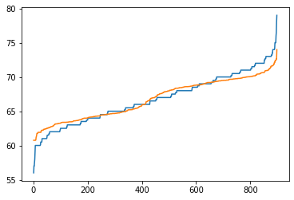

```python
x = np.linspace(1,898, 898)
plt.plot(x, sorted(y))
plt.plot(x, sorted(y_prediction))
```